# Part 5: Homography + RANSAC

```python
len(inliers_X1)
```

```
113
```

```python
coordinates_im1_inliers=[]
coordinates_im2_inliers=[]
for i in range(0,len(inliers_X1)):
    coordinates_im1_inliers.append([inliers_X1[i][0],inliers_X1[i][1]])
    coordinates_im2_inliers.append([inliers_X2[i][0]+im2.shape[1],inliers_X2[i][1]])
```

Displaying the inlier matches obtained from applying RANSAC:

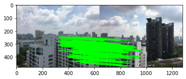

```python
im_concat = cv2.hconcat([im1, im2])
image=im_concat.copy()
for i in range(0,len(inliers_X1)):
     image = cv2.line(im_concat,coordinates_im1_inliers[i],coordinates_im2_inliers[i],(0, 255, 0),thickness=5)

plt.imshow(image)
```

```python
len(inliers_X1)
```

[output not shown]

Stitching the images: For stitching the images, the homography matrix is computed using the inliers obtained from RANSAC method. Here, the 1st image that is to be stitched is interpolated to prevent occurence of darkening effect from stitching. The inliers for the interpolated image are also scaled accordingly and used for computation of homography matrix.

```python
inliers_X1_scaled=[]
inliers_X2_scaled=[]
for i in range(0,len(inliers_X1)):
    inliers_X1_scaled.append([4*inliers_X1[i][0],4*inliers_X1[i][1]])
    inliers_X2_scaled.append([4*inliers_X2[i][0],4*inliers_X2[i][1]])
```

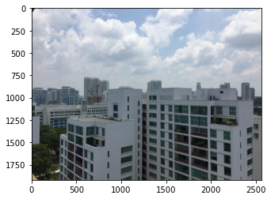

```python
#im1=plt.imread('im01.jpg')

im1_interpolate=cv2.resize(im1,(4*im1.shape[1],4*im1.shape[0]),fx=4, fy=4, interpolation=cv2.INTER_CUBIC)
plt.imshow(im1_interpolate)
```

Computing the homography matrix:

```python
A = []
b = []
for i in range(len(inliers_X1)):
    s_x, s_y = inliers_X1_scaled[i][0:2]
   # coordinates_1_hm.append([s_x,s_y,1])
    d_x, d_y = inliers_X2[i][0:2]
    #coordinates_2_hm.append([d_x,d_y,1])
    A.append([s_x, s_y, 1, 0, 0, 0, -(d_x)*(s_x), -(d_x)*(s_y),-d_x])
    A.append([0, 0, 0, s_x, s_y, 1, -(d_y)*(s_x), -(d_y)*(s_y),-d_y])
    b += [d_x, d_y]
A = np.array(A)
#h = np.linalg.lstsq(A, b,rcond=-1)[0]
#h = np.concatenate((h, [1]), axis=-1)

import scipy.linalg as linalg
A = np.array(A)
U, Sigma, V_transpose = linalg.svd(A)

H = np.reshape(V_transpose[-1], (3,3))
```

```python
H
```

```
array([[ 8.09521016e-04, -3.60129189e-05, -9.55843092e-01],
       [ 1.99895556e-04,  6.61224606e-04, -2.93872032e-01],
       [ 7.02080736e-07, -5.63778219e-08,  1.44128963e-03]])
```

```python
H
```

```
array([[ 3.24579024e-03, -1.38128829e-04, -9.59160074e-01],
       [ 7.57053613e-04,  2.68324795e-03, -2.82827511e-01],
       [ 2.66597151e-06, -1.46999358e-07,  1.49128263e-03]])
```

Transforming the extreme points, i.e [(0,0), (0,height),(height,width),(width,0)] to define the shape of the canvas which in turn needs to accommodate the coordinates of the 2nd image as well as all transformed coordinates of 1st image and ensuring that points do not get cut off.

```python
h1,w1=im1_interpolate.shape[0:2]
```

[figure not shown]

```python
#plt.imshow(im1_interpolate)
```

```python
#im1[h1-1,w1-1]
```

[output not shown]

```python
h1,w1=im1_interpolate.shape[0:2]
vertex = np.array([[0, 0, 1], [0, h1, 1], [w1, 0, 1], [w1, h1, 1]]);
pos = np.dot(H ,vertex.T); #position of transformed vertices
```

```python
pos[1,:]/pos[2,:]
```

```
array([-203.89519617,  731.91811645,   67.26965173,  475.1551438 ])
```

```python
row=(pos[1,:]/pos[2,:]).astype(int)
col=(pos[0,:]/pos[2,:]).astype(int)
```

```python
col_min = min(col)
col_max = max(col)
row_min = min(row)
row_max = max(row)
```

```python
col_max
```

```
344
```

Defining the canvas:

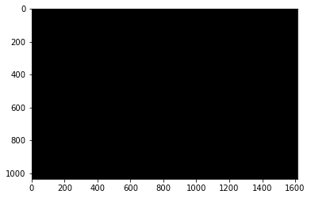

```python
canvas1 = np.zeros([row_max-row_min+100, col_max-col_min+500, 3])
canvas1.shape
plt.imshow(canvas1)
```

```python
im2.shape[1]
```

```
640
```

```python
im2[479,639]
```

```
array([28, 23, 20], dtype=uint8)
```

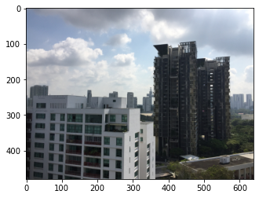

```python
im2=plt.imread('im02.jpg')
plt.imshow(im2)
```

Placing image 2 onto the canvas:

```python
for y in range(0,im2.shape[0]):

    for x in range(0,im2.shape[1]):

        tx2 = x-col_min
        ty2 = y-row_min
        if ty2<canvas1.shape[0] and tx2<canvas1.shape[1]:
            canvas1[ty2,tx2] = im2[y,x]
```

```
WARNING:matplotlib.image:Clipping input data to the valid range for imshow with RGB data ([0..1] for floats or [0..255] for integers).
```

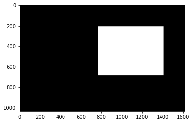

```python
plt.imshow(canvas1)
```

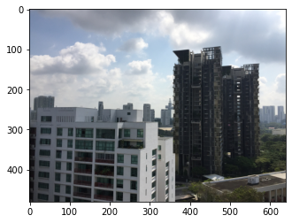

```python
plt.imshow(im2/255)
```

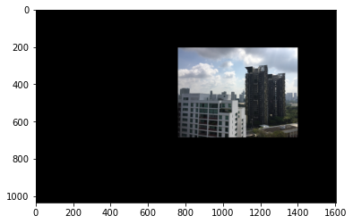

```python
plt.imshow(canvas1/255)
```

```python
h1
```

```
1920
```

Transforming every coordinate of image 1 using the computed homography matrix and placing the same on to the canvas:

```
WARNING:matplotlib.image:Clipping input data to the valid range for imshow with RGB data ([0..1] for floats or [0..255] for integers).
```

[figure not shown]

```python
for y in range(0, h1):
    for x in range(0, w1):
        pixel = np.array([x,
                          y,
                          1])

        # Resource_pixel = np.asarray(np.asmatrix(inv_my_homo) * np.asmatrix(pixel))
        #Resource_pixel = np.asarray(np.asmatrix(My_Homography_arr) * np.asmatrix(pixel))
        Resource_pixel = np.asarray(H * np.asmatrix(pixel).T)
        # Coordinate scale
        trans_x = Resource_pixel[0][0] / Resource_pixel[2][0]
        trans_y = Resource_pixel[1][0] / Resource_pixel[2][0]

        # Continue that pixels not matched
#         if (trans_x < 0 or trans_y < 0
#                 or trans_x > f2.shape[0] - 1 or trans_y > f2.shape[1] - 1):

# #        if (trans_x < 0 and trans_y < 0
# #                 and trans_x > f2.shape[0] - 1 and trans_y > f2.shape[1] - 1):
#              continue

        # divided by two parts with integer & decimal number
        tx = int(trans_x) -col_min
        ty = int(trans_y) -row_min
        a = trans_x - tx
        b = trans_y - ty

        #if tx<canvas1.shape[0] and ty<canvas1.shape[1]:
        canvas1[ty,tx]=im1_interpolate[y,x]

        # Bilinear Interpolation
#         if ty+1<im1.shape[0] and tx+1<im1.shape[1]:
#             canvas1[ty][tx] = ((((1.0 - a) * (1.0 - b)) * im1[ty,tx])
#                          + ((a * (1.0 - b)) * im1[ty,tx + 1])
#                          + ((a * b) * im1[ty + 1,tx + 1])
#                          + (((1.0 - a) * b) * im1[ty + 1,tx]))

# Image stitch
# M, N = f1.shape[:2]
# f_stitched = np.copy(warped)
#f_stitched[0:M, 0:N, :] = f1

# Plot
# plt.subplot(221)
# plt.imshow(f1)
# plt.axis('off')
# coordinates_2=np.array(coordinates_2)
# coordinates_1=np.array(coordinates_1)
# plt.scatter(coordinates_2[:, 0], coordinates_2[:, 1], marker='x')
# plt.subplot(222)
# plt.imshow(f2)
# plt.axis('off')
# plt.scatter(coordinates_1[:, 0], coordinates_1[:, 1], marker='x')
# plt.subplot(223)
plt.imshow(canvas1)
plt.axis('off')
#plt.subplot(224)
#plt.imshow(f_stitched)
#plt.axis('off')
plt.show()
```

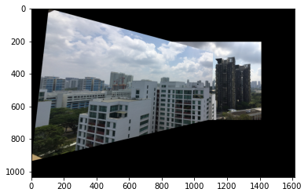

```python
plt.imshow(canvas1/255)
```

Stitching image 2 to image 1: ii) In order to stitch image 2 to image 1,image 2 is first interpolated following which the scaled inlier coordinates of image 2 and the original inlier coordinates of image 1 are used to recompute the homography matrix i)The inverse of the computed homography matrix is then used to transform the coordinates of image 2.

```python
H_inv=linalg.pinv(H)
```

```python
import numpy as np
A = []
b = []
for i in range(len(coordinates_1)):
    s_x, s_y = coordinates_1[i]
    d_x, d_y = coordinates_2[i]
    A.append([s_x, s_y, 1, 0, 0, 0, -(d_x)*(s_x), -(d_x)*(s_y),-d_x])
    A.append([0, 0, 0, s_x, s_y, 1, -(d_y)*(s_x), -(d_y)*(s_y),-d_y])
    b += [d_x, d_y]
A = np.array(A)
#h = np.linalg.lstsq(A, b,rcond=-1)[0]
#h = np.concatenate((h, [1]), axis=-1)

import scipy.linalg as linalg
A = np.array(A)
U, Sigma, V_transpose = linalg.svd(A)

H = np.reshape(V_transpose[-1], (3,3))
H
```

```
array([[-1.09668558e-03, -6.04686299e-04,  6.33587714e-01],
       [-1.00716378e-03, -1.35638246e-03,  7.73665147e-01],
       [-3.17272920e-06, -3.09946703e-06,  2.10400899e-03]])
```

```python
coordinates_1
```

```
[array([372, 400]),
 array([499, 340]),
 array([540, 295]),
 array([147, 228]),
 array([341, 467])]
```

Interpolating Image 2 and displaying the interpolated image:

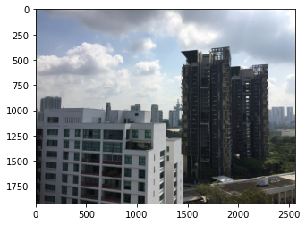

```python
#im2=plt.imread('im02.jpg')

im2_interpolate=cv2.resize(im2,(4*im2.shape[1],4*im2.shape[0]),fx=4, fy=4, interpolation=cv2.INTER_CUBIC)
plt.imshow(im2_interpolate)
```

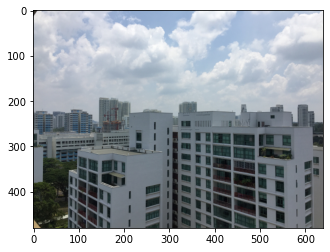

```python
plt.imshow(im1)
```

Computing Homography Matrix:

```python
A = []
b = []
for i in range(len(inliers_X1)):
    s_x, s_y = inliers_X1[i][0:2]
   # coordinates_1_hm.append([s_x,s_y,1])
    d_x, d_y = inliers_X2_scaled[i][0:2]
    #coordinates_2_hm.append([d_x,d_y,1])
    A.append([s_x, s_y, 1, 0, 0, 0, -(d_x)*(s_x), -(d_x)*(s_y),-d_x])
    A.append([0, 0, 0, s_x, s_y, 1, -(d_y)*(s_x), -(d_y)*(s_y),-d_y])
    b += [d_x, d_y]
A = np.array(A)
#h = np.linalg.lstsq(A, b,rcond=-1)[0]
#h = np.concatenate((h, [1]), axis=-1)

import scipy.linalg as linalg
A = np.array(A)
U, Sigma, V_transpose = linalg.svd(A)

H = np.reshape(V_transpose[-1], (3,3))
```

Obtaining the inverse of homography matrix to stitch image 2 to image 1:

```python
H_inv=linalg.inv(H)
```

```python
im1.shape
```

```
(480, 640, 3)
```

```python
im2_interpolate.shape[0:2]
```

```
(1920, 2560)
```

Transforming the extreme points, i.e [(0,0), (0,height),(height,width),(width,0)] to define the shape of the canvas which in turn needs to accommodate the coordinates of the 1st image as well as all transformed coordinates of 2nd image and ensuring that points do not get cut off.

```python
h2,w2=im2_interpolate.shape[0:2]
vertex = np.array([[0, 0, 1], [0, h2, 1], [w2, 0, 1], [w2, h2, 1]]);
pos = np.dot(H_inv ,vertex.T); #position of transformed vertices
```

```python
row=(pos[1,:]/pos[2,:]).astype(int)
col=(pos[0,:]/pos[2,:]).astype(int)
```

```python
row_min
```

[output not shown]

```python
col_min = min(col)
col_max = max(col)
row_min = min(row)
row_max = max(row)
```

```python
if col_min>1:
    col_min=1
if row_min>1:
    row_min=1
```

Defining the initial canvas:

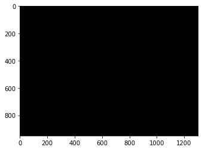

```python
canvas2 = np.zeros([row_max-row_min+50, col_max-col_min, 3])
canvas2.shape
plt.imshow(canvas2)
```

Placing image 1 onto the canvas:

```python
for y in range(0,im1.shape[0]):

    for x in range(0,im1.shape[1]):

        tx2 = x - col_min
        ty2 = y -row_min
        #if ty2<canvas2.shape[0] and tx2<canvas2.shape[1]:
        canvas2[ty2,tx2] = im1[y,x]
```

Displaying Canvas with image 1:

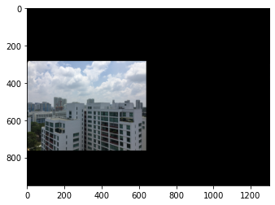

```python
plt.imshow(canvas2/255)
```

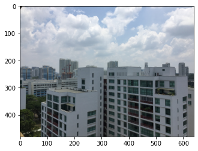

```python
plt.imshow(im1)
```

```python
print(h2,w2)
```

```
1920 2560
```

Transforming every coordinate of image 2 and placing the transformed image 2 accordingly on to the canvas:

```
WARNING:matplotlib.image:Clipping input data to the valid range for imshow with RGB data ([0..1] for floats or [0..255] for integers).
```

[figure not shown]

```python
for y in range(0, h2):
    for x in range(0, w2):
        pixel = np.array([x,
                          y,
                          1])

        # Resource_pixel = np.asarray(np.asmatrix(inv_my_homo) * np.asmatrix(pixel))
        #Resource_pixel = np.asarray(np.asmatrix(My_Homography_arr) * np.asmatrix(pixel))
        Resource_pixel = np.asarray(H_inv * np.asmatrix(pixel).T)
        # Coordinate scale
        trans_x = Resource_pixel[0][0] / Resource_pixel[2][0]
        trans_y = Resource_pixel[1][0] / Resource_pixel[2][0]

        # Continue that pixels not matched
#         if (trans_x < 0 or trans_y < 0
#                 or trans_x > f2.shape[0] - 1 or trans_y > f2.shape[1] - 1):

# #        if (trans_x < 0 and trans_y < 0
# #                 and trans_x > f2.shape[0] - 1 and trans_y > f2.shape[1] - 1):
#              continue

        # divided by two parts with integer & decimal number
        tx = int(trans_x) -col_min
        ty = int(trans_y) -row_min
        a = trans_x - tx
        b = trans_y - ty

        #if tx<canvas2.shape[0] and ty<canvas2.shape[1]:
        canvas2[ty,tx]=im2_interpolate[y,x]

        # Bilinear Interpolation
#         if ty+1<im1.shape[0] and tx+1<im1.shape[1]:
#             canvas1[ty][tx] = ((((1.0 - a) * (1.0 - b)) * im1[ty,tx])
#                          + ((a * (1.0 - b)) * im1[ty,tx + 1])
#                          + ((a * b) * im1[ty + 1,tx + 1])
#                          + (((1.0 - a) * b) * im1[ty + 1,tx]))

# Image stitch
# M, N = f1.shape[:2]
# f_stitched = np.copy(warped)
#f_stitched[0:M, 0:N, :] = f1

# Plot
# plt.subplot(221)
# plt.imshow(f1)
# plt.axis('off')
# coordinates_2=np.array(coordinates_2)
# coordinates_1=np.array(coordinates_1)
# plt.scatter(coordinates_2[:, 0], coordinates_2[:, 1], marker='x')
# plt.subplot(222)
# plt.imshow(f2)
# plt.axis('off')
# plt.scatter(coordinates_1[:, 0], coordinates_1[:, 1], marker='x')
# plt.subplot(223)
plt.imshow(canvas2)
plt.axis('off')
#plt.subplot(224)
#plt.imshow(f_stitched)
#plt.axis('off')
plt.show()
```

Displaying the canvas with stitched images:

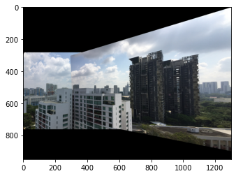

```python
plt.imshow(canvas2/255)
```